# DSCI 415: Unsupervised Learning Final Project

Brad Erickson & Will Henschell

# Anime Recommender System

### Libraries needed

```r
library(recommenderlab)
library(proxy)
library(class)
library(data.table)
```

### DATA

Our dataset comes from [Kaggle](https://www.kaggle.com/CooperUnion/anime-recommendations-database). This data is formatted into 2 separate data files that were cleaned and combined. *rating.csv* included a user_id, anime_id, and a rating on a scale from -1 to 10, with -1 being watched and not rated and 10 being the best rating. *anime.csv* includes information about each anime movie or series. Data cleaning was done in Python.To make the file manageable, the movie ratings were dropped from the dataset, leaving only the reviews for TV series. The data for users with at less than 10 “good” ratings (a rating of 7 or more) were dropped from the data set, as well as TV series with less than 10 “good” reviews. This reduced the dataset to a more manageable size. The data set was then transposed to have an anime title for each column header, and each user’s ratings as a row, which was then converted to a real ratings matrix. Due to the large amount of data used, we use a *.RData* file to pull in the necessary large variables.

```r
# get the anime.RData file from the data folder
load(file.choose())
colnames(tv[1:10])
```

```
##  [1] ".hack..Roots"
##  [2] ".hack..Sign"
##  [3] ".hack..Tasogare.no.Udewa.Densetsu"
##  [4] "X009.1"
##  [5] "X07.Ghost"
##  [6] "X11eyes"
##  [7] "X12.sai...Chicchana.Mune.no.Tokimeki"
##  [8] "X3.Choume.no.Tama..Uchi.no.Tama.Shirimasenka."
##  [9] "X30.sai.no.Hoken.Taiiku"
## [10] "X91.Days"
```

### MODEL SELECTION EVALUATION

```r
#Testing all recommenders
explore.scheme = evaluationScheme(tv.mat, method= 'split', train = 0.85, k = 1, given = 1, goodRating = 7)

#Setting algorithms to test
explore.algorithms <- list(
  'random items' = list(name = 'RANDOM', param = list(normalize = 'Z-score')),
  'popular items' = list(name = 'POPULAR', param = list(normalize = 'Z-score')),
  'user-based CF' = list(name = 'UBCF', param = list(normalize = 'Z-score', method = 'Cosine', nn=50)),
  'item-based CF' = list(name = 'IBCF', param = list(normalize = 'Z-score'))
  )

#Evaluating all algorithms
explore.results = evaluate(explore.scheme, explore.algorithms, n=c(1, 3, 5, 10, 15, 20))
```

The code above was run to see which recommender algorithm best fit our data for giving out 1, 3, 5, 10, 15, and 20 recommendations.

### Plotting model results for comparison (TPR and FPR)

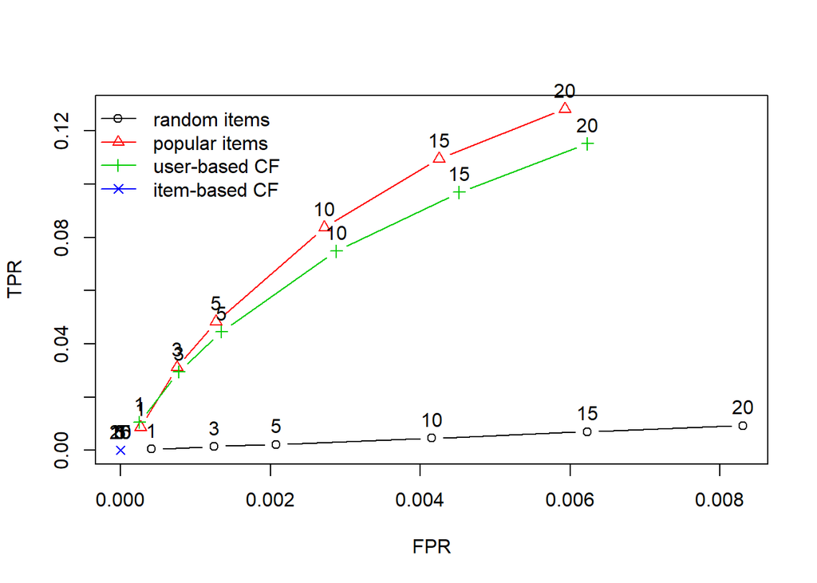

```r
plot(explore.results, annotate = 1:4, legend = 'topleft')
```

### Plotting model results for comparison (precision and recall)

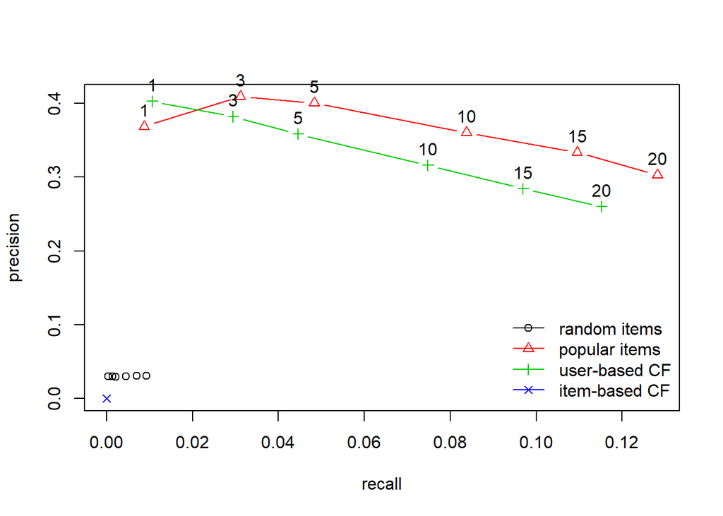

```r
plot(explore.results, 'prec/rec', annotate = 2:3)
```

### Plot Notes

Both plots indicate that the popular items algorithm is the best recommendation algorithm to give recommendations at all sizes of recommendation lists, unless the user only wants one recommendation. The best algorithm to use if the user just wants one recommendation is the user-based collaborative filtering algorithm.

### FINAL RECOMMENDER MODEL

```r
#Creating test and training data for final model
tv.scheme = evaluationScheme(tv.mat, method= 'split', train = 0.666666, given = 1, goodRating = 7)

#Fitting the popular items recommender on the training data
tv.pop.rec = Recommender(getData(tv.scheme, 'train'), method = 'POPULAR')
```

### Creating top 10 list for all users

```r
new.users.top10 = predict(tv.pop.rec, getData(tv.scheme, 'known'), n=10)
as(new.users.top10, 'list')
```

### Model Notes

The code above separates the data into a test set and training set of 2/3, 1/3 to be used with the recommendation algorithm.

### Creating top 10 list for sample of 10

```r
sample.new.users.top10 = predict(tv.pop.rec, getData(tv.scheme, 'known')[1:10,], n=10)
sample.new.users.top10.list <- as(sample.new.users.top10, 'list')
```

### Printing top 10 list for sample of 10

```r
sample.new.users.top10.list
```

```
## [[1]]
##  [1] "Fullmetal.Alchemist..Brotherhood"   "Death.Note"
##  [3] "Steins.Gate"                        "Code.Geass..Hangyaku.no.Lelouch.R2"
##  [5] "Code.Geass..Hangyaku.no.Lelouch"    "Clannad..After.Story"
##  [7] "Tengen.Toppa.Gurren.Lagann"         "Shingeki.no.Kyojin"
##  [9] "Cowboy.Bebop"                       "Toradora."
##
## [[2]]
##  [1] "Fullmetal.Alchemist..Brotherhood"   "Death.Note"
##  [3] "Steins.Gate"                        "Code.Geass..Hangyaku.no.Lelouch.R2"
##  [5] "Code.Geass..Hangyaku.no.Lelouch"    "Clannad..After.Story"
##  [7] "Tengen.Toppa.Gurren.Lagann"         "Shingeki.no.Kyojin"
##  [9] "Cowboy.Bebop"                       "Toradora."
##
## [[3]]
```

[output cut: 54 more lines]

### Smaller Sample Model Notes

This code creates a recommendation model from the training set using the popular items algorithm and creates predictions for all users. However, for the sake of practicality, a smaller sample of 10 users were predicted. This list shows that the same shows are generally suggested for all users, which makes sense because they are the most popular items. This says a lot about anime, because people are more likely to watch good series and discuss them, which makes them popular. Some of the top recommended shows for these 10 users are: Fullmetal Alchemist: Brotherhood, Death Note, and Steins Gate.

### Creating and cleaning a string version of the list for the sample of 10

```r
sample.new.users.top10.string <- as.character(sample.new.users.top10.list)
sample.new.users.top10.string <- gsub('c\\(', '', sample.new.users.top10.string)
sample.new.users.top10.string <- gsub('\\)', '', sample.new.users.top10.string)
```

### Preparing the counts of anime TV series that appear in the top 10 list for 10 users

```r
sample.new.users.top10.list.split <- unlist(strsplit(sample.new.users.top10.string, split = ','))
sample.new.users.top10.list.split.dt <- data.table(sample.new.users.top10.list.split)
colnames(sample.new.users.top10.list.split.dt)[colnames(sample.new.users.top10.list.split.dt)=="sample.new.users.top10.list.split"] <- "anime_title"
sample.new.users.top10.anime.counts <- sample.new.users.top10.list.split.dt[, .(count = .N), by = sample.new.users.top10.list.split.dt[,1]]
```

### Printing top anime counts for sample of 10 users

```r
print(sample.new.users.top10.anime.counts)
```

```
##                               anime_title count
##  1:    "Fullmetal.Alchemist..Brotherhood"    10
##  2:                          "Death.Note"     9
##  3:                         "Steins.Gate"    10
##  4:  "Code.Geass..Hangyaku.no.Lelouch.R2"    10
##  5:     "Code.Geass..Hangyaku.no.Lelouch"     9
##  6:                "Clannad..After.Story"    10
##  7:          "Tengen.Toppa.Gurren.Lagann"    10
##  8:                  "Shingeki.no.Kyojin"     9
##  9:                        "Cowboy.Bebop"    10
## 10:                           "Toradora."    10
## 11:                        "Angel.Beats."     3
```

### Recommendation Count Notes

The counts of each recommendation were found, and it appears that users were recommended Angel Beats if they had already seen and rated one of the top 10 TV series, but were otherwise recommended the top 10 shows (with some altering of position).

# Pokemon Cluster Analysis

### Libraries

```r
library(cluster)
library(dplyr)
library(factoextra)
library(stringr)
```

### Overall data

Our data comes from [Kaggle](https://www.kaggle.com/rounakbanik/pokemon). Each row in the dataset is a different Pokemon. We decided to create a new column that includes *Type1, Type2, and Pokemon* for creating a detailed row name to appear in our structure. We cut the data down to only use the first 151 Pokemon for observing clusters more clearly later on.

```r
# get the pokemon.csv file from the data folder
pokemon = read.csv(file.choose(), header=TRUE, sep=",", stringsAsFactors = FALSE)
pokemon <- pokemon %>% mutate(type = paste(type1, type2) %>% str_split(., ' ') %>% lapply(., 'sort') %>%  lapply(., 'paste', collapse=' ') %>% unlist(.))
pokemon <- pokemon %>% mutate(name.type = paste(type, name))
pokemon <- pokemon[1:151,]
rownames(pokemon) <- pokemon$name.type
pokemon.mat <- pokemon[2:19]
colnames(pokemon)
```

```
##  [1] "abilities"         "against_bug"       "against_dark"
##  [4] "against_dragon"    "against_electric"  "against_fairy"
##  [7] "against_fight"     "against_fire"      "against_flying"
## [10] "against_ghost"     "against_grass"     "against_ground"
## [13] "against_ice"       "against_normal"    "against_poison"
## [16] "against_psychic"   "against_rock"      "against_steel"
## [19] "against_water"     "attack"            "base_egg_steps"
## [22] "base_happiness"    "base_total"        "capture_rate"
## [25] "classfication"     "defense"           "experience_growth"
## [28] "height_m"          "hp"                "japanese_name"
## [31] "name"              "percentage_male"   "pokedex_number"
## [34] "sp_attack"         "sp_defense"        "speed"
## [37] "type1"             "type2"             "weight_kg"
## [40] "generation"        "is_legendary"      "type"
## [43] "name.type"
```

### Data for clustering

We truncate our data down to the effectiveness against each type for clustering purposes. An example of row in our data matrix is shown below.

```r
colnames(pokemon[2:19])
```

```
##  [1] "against_bug"      "against_dark"     "against_dragon"   "against_electric"
##  [5] "against_fairy"    "against_fight"    "against_fire"     "against_flying"
##  [9] "against_ghost"    "against_grass"    "against_ground"   "against_ice"
## [13] "against_normal"   "against_poison"   "against_psychic"  "against_rock"
## [17] "against_steel"    "against_water"
```

```r
pokemon.mat[1,]
```

```
##                        against_bug against_dark against_dragon against_electric
## grass poison Bulbasaur           1            1              1              0.5
##                        against_fairy against_fight against_fire against_flying
## grass poison Bulbasaur           0.5           0.5            2              2
##                        against_ghost against_grass against_ground against_ice
## grass poison Bulbasaur             1          0.25              1           2
##                        against_normal against_poison against_psychic
## grass poison Bulbasaur              1              1               2
##                        against_rock against_steel against_water
## grass poison Bulbasaur            1             1           0.5
```

### Finding k

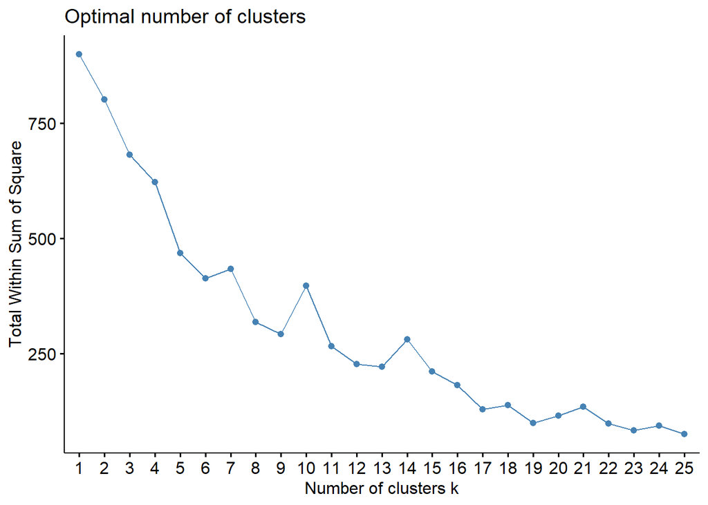

```r
fviz_nbclust(pokemon.mat,kmeans,k.max=25,method="wss")
```

#### silhouette

The silhouette method recommends we use 25 clusters.

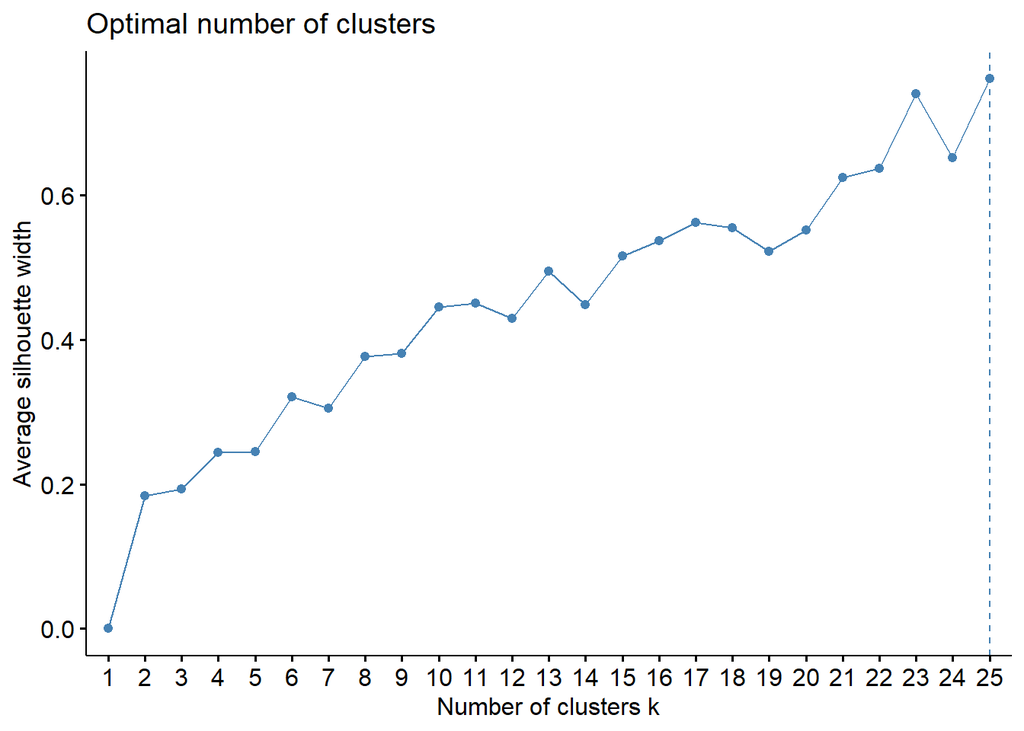

```r
fviz_nbclust(pokemon.mat,kmeans,k.max=25,method="silhouette")
```

#### gap_stat

Lastly, the gap_stat method indicates 1 cluster is sufficient.

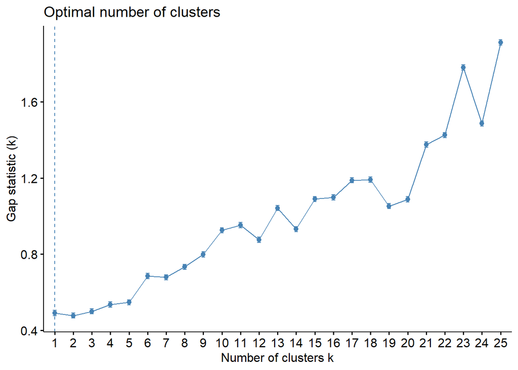

```r
fviz_nbclust(pokemon.mat,kmeans,k.max=25,method="gap_stat")
```

### Hierarchical clustering

We choose k = 18 which is the total number of types possible. Using ward’s distance, we get a dendrogram with color cuts.

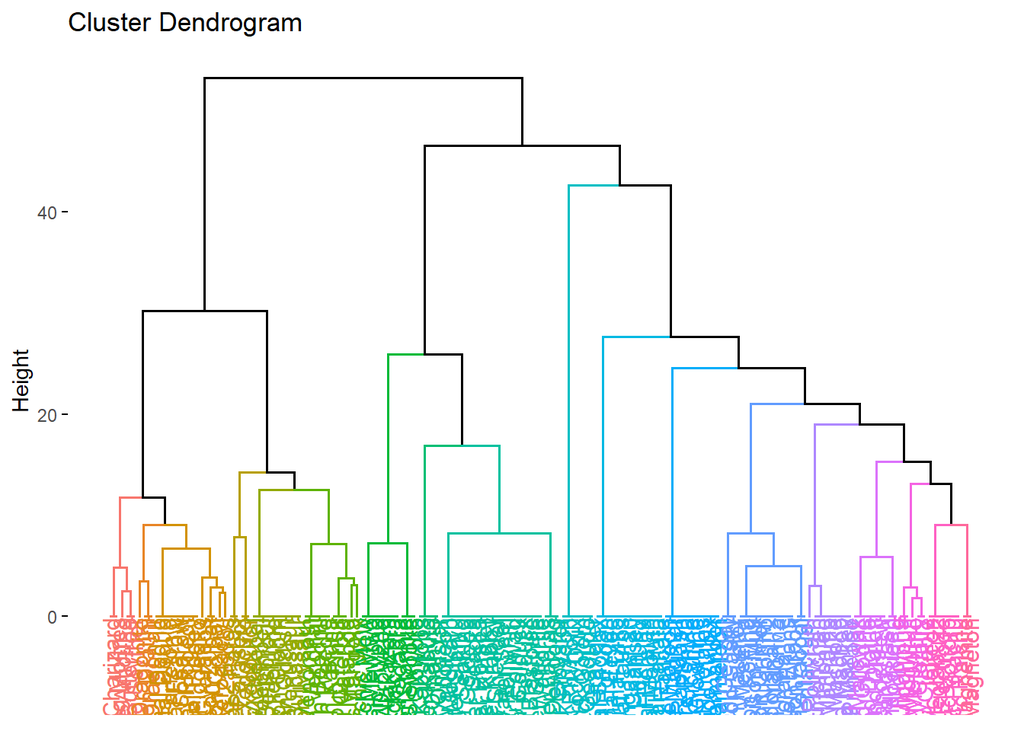

```r
k = 18
pokemon.dist <- dist(pokemon.mat)
pokemon.hclust <- hclust(pokemon.dist, method="ward.D")
fviz_dend(pokemon.hclust, k=k)
```

After zooming in on the branches of this tree structure, we find clustering based on types.

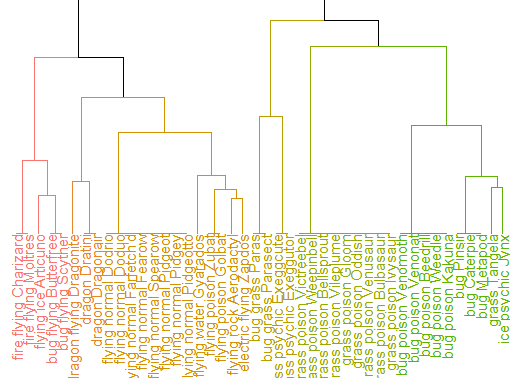

In the first chunk of clusters, we notice a common trend of flying Pokemon on the left and the grass/bug Pokemon on the right.

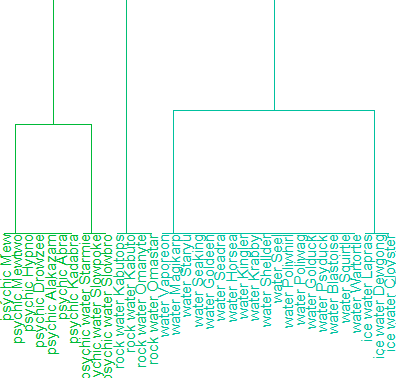

Continuing on, we see the next piece of the cluster contains psychic Pokemon in one chunk and water Pokemon in another.

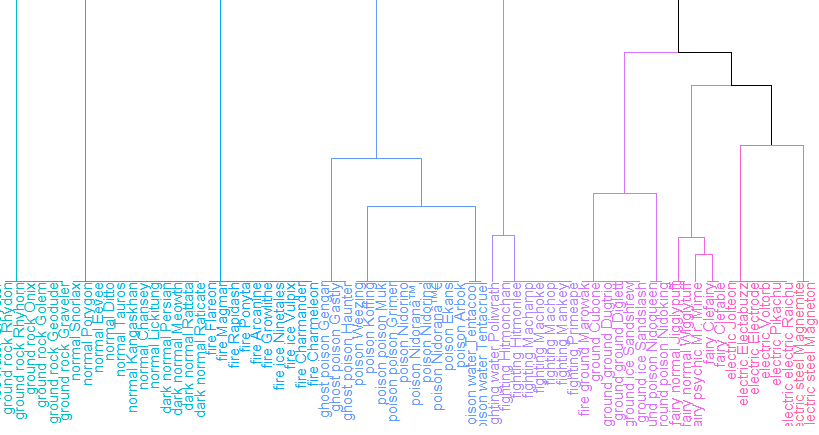

# Seinfeld Text Mining

### Libraries and functions used

The *cbind.all* function is for appending columns to a dataframe and the *clean.text* is from Dr. Deppa for cleaning the text.

```r
library(syuzhet)
library(dplyr)
library(wordcloud)
library(tm)
cbind.all <- function (...) {
  nm <- list(...)
  nm <- lapply(nm, as.matrix)
  n <- max(sapply(nm, nrow))
  do.call(cbind, lapply(nm, function(x) rbind(x, matrix(, n - nrow(x), ncol(x)))))
}

clean.text <- function(some_txt){
  some_txt = gsub("(RT|via)((?:\\b\\W*@\\w+)+)", "", some_txt)
  some_txt = gsub("@\\w+", "", some_txt)
  some_txt = gsub("[[:punct:]]", "", some_txt)
  some_txt = gsub("[[:digit:]]", "", some_txt)
  some_txt = gsub("http\\w+", "", some_txt)
  some_txt = gsub("[ \t]{2,}", "", some_txt)
  some_txt = gsub("^\\s+|\\s+$", "", some_txt)
  # define "tolower error handling" function
  try.tolower = function(x)
  {
    y = NA
    try_error = tryCatch(tolower(x), error=function(e) e)
    if (!inherits(try_error, "error"))
      y = tolower(x)
    return(y)
  }
  some_txt = sapply(some_txt, try.tolower)
  some_txt = some_txt[some_txt != ""]
  names(some_txt) = NULL
  return(some_txt)
}
```

### Data

The data is supplied by Dr. Deppa. We are only using the *scripts.csv* datafile from the dataset. This file includes the dialogue, who said it, and what season/episode they said it in.

```r
# get the scripts.csv file from the data folder
show = read.csv(file.choose(), header=TRUE, sep=",", stringsAsFactors = FALSE)
show.title <- "Seinfeld"
seasons <- unique(show$Season)
colnames(show)
```

```
## [1] "X"         "Character" "Dialogue"  "EpisodeNo" "SEID"      "Season"
```

### Sentiment analysis

We ran a sentiment analysis on the data. We will explore both by episode per season, overall average per season, and overall average.  
#### By season With the per episode by season, we see the plots below. Each of the black lines indicate a different episode and the thicker red line is for the average episode sentiment for that season.

```r
show.sentiment <- data.frame()
episodes.sentiment <- data.frame()
for (i in seasons) {
  season.data <- show %>% filter(Season==i)
  episodes <- unique(season.data$EpisodeNo)
  season.sentiment <- data.frame()
  title <- paste(show.title,": Season ",i," sentiment by episode")
  cat(paste("#####", title))

  ### sentiment of episode plus season overall
  plot(0,0, main=title, xlab = "Normalized Narrative Time", ylab = "Scaled Sentiment", type="n", xlim=c(-1,101), ylim=c(-1.01, 1.01))
  for (j in episodes) {
    episode.data <- season.data %>% filter(EpisodeNo==j)
    episode.sentences <- get_sentences(episode.data$Dialogue)
    episode.sentiment <- get_sentiment(episode.sentences)
    episode.sentiment.values <- get_dct_transform(episode.sentiment, low_pass_size = 5, x_reverse_len = 100, scale_vals = F, scale_range = T)
    season.sentiment <- cbind.all(season.sentiment, episode.sentiment.values)
    episodes.sentiment <- cbind.all(episodes.sentiment, episode.sentiment.values)
    lines(episode.sentiment.values)
  }

  season.sentiment.means <- rowMeans(season.sentiment)
  lines(season.sentiment.means, col="firebrick", lwd = 5)
  show.sentiment <- cbind.all(show.sentiment, season.sentiment.means)
  cat("\n")
  Sys.sleep(1)
}
```

##### Seinfeld : Season 1 sentiment by episode

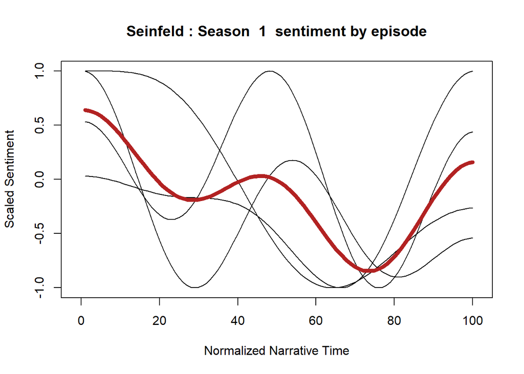

##### Seinfeld : Season 2 sentiment by episode

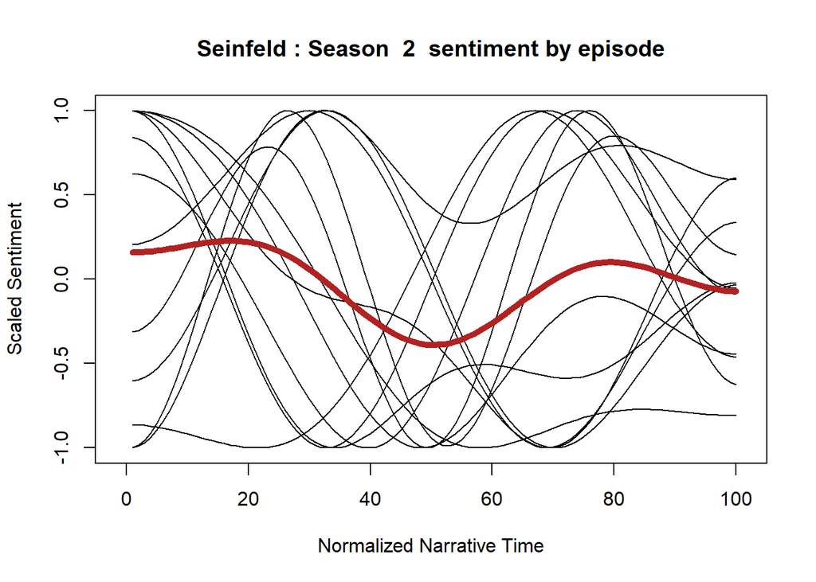

##### Seinfeld : Season 3 sentiment by episode

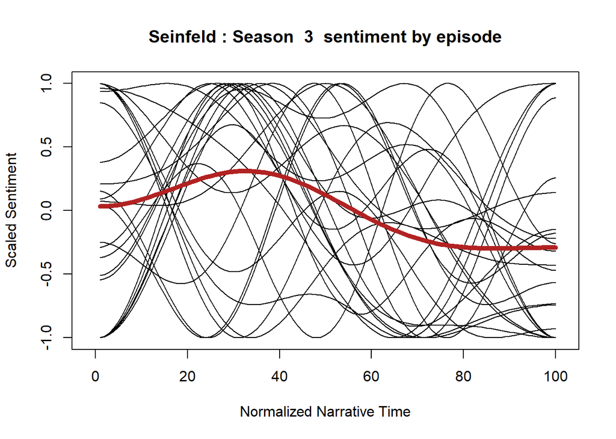

##### Seinfeld : Season 4 sentiment by episode

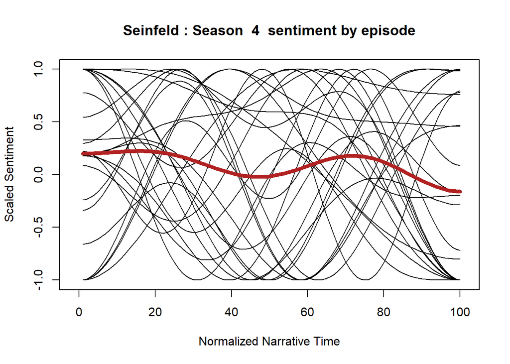

##### Seinfeld : Season 5 sentiment by episode

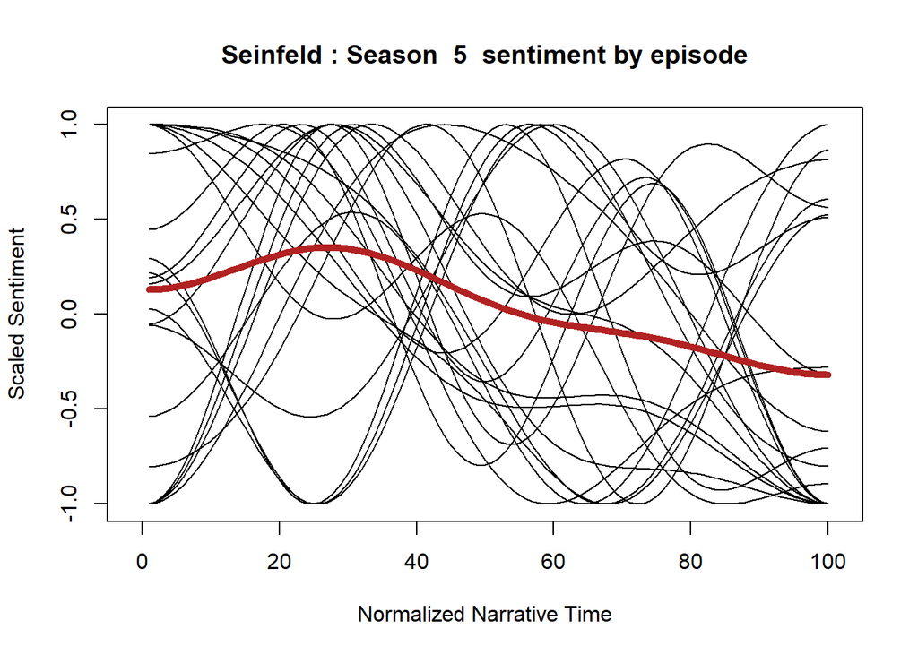

##### Seinfeld : Season 6 sentiment by episode

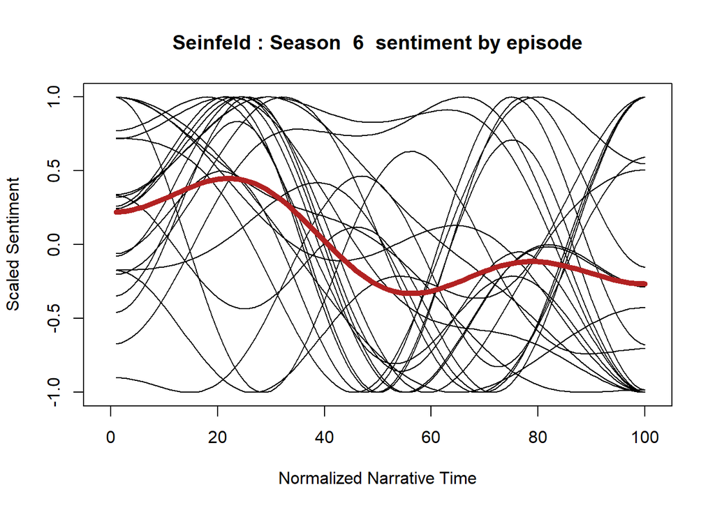

##### Seinfeld : Season 7 sentiment by episode

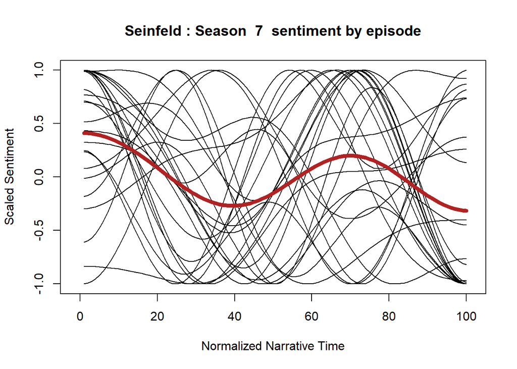

##### Seinfeld : Season 8 sentiment by episode

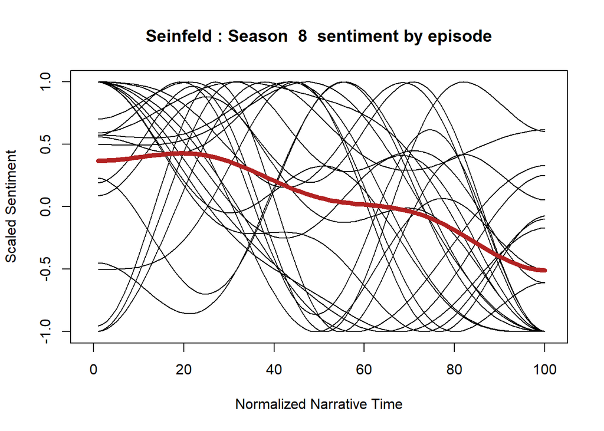

##### Seinfeld : Season 9 sentiment by episode

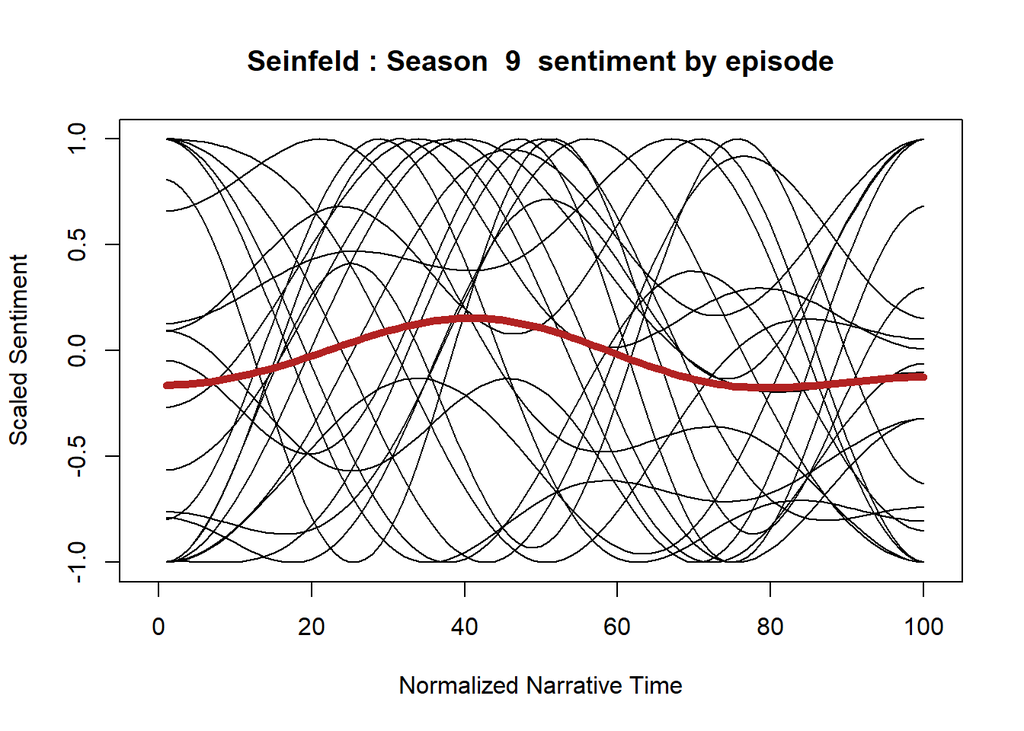

#### Overall

Next we looked at the overall sentiment. The thinner colored lines represent the season averages we saw in the previous plots. Once again, the thick red line is the average sentiment for an episode based on all episodes. From this line, we can simply say on average, Seinfeld episodes started with a relatively good tone and ended with a relatively poor tone.

```r
title <- paste(show.title,": Sentiment by season")
cat(paste("#####", title))
```

##### Seinfeld : Sentiment by season

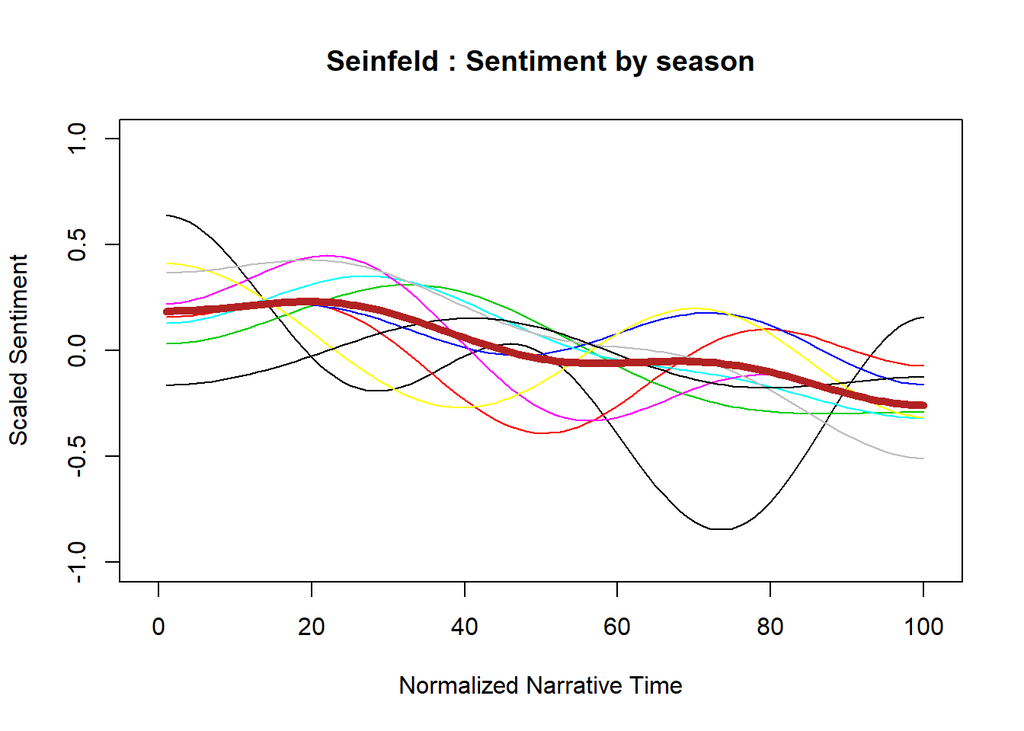

```r
plot(0,0, main=title, xlab = "Normalized Narrative Time", ylab = "Scaled Sentiment", type="n", xlim=c(-1,101), ylim=c(-1.01, 1.01))
for (i in seasons) {
  lines(show.sentiment[,i], col=i)
}
lines(rowMeans(episodes.sentiment), col="firebrick", lwd = 5)
```

```r
cat("\n")
```

### Wordclouds

For the next piece of this analysis, we looked at both individual and a comparison word cloud. #### Individual To begin, we must filter the data down for each character. If multiple characters spoke the same thing at once, we counted it for both characters. For example: if Jerry and George both yelled “What?”, then we include this dialogue in both Jerry and George’s analysis. We removed the English stop words to have a better understanding of what each character said.

```r
main.characters <- c("JERRY", "GEORGE", "ELAINE", "KRAMER")
for (i in main.characters) {
  character.data <- show %>% filter(grepl(i,Character))
  character.text.clean <- clean.text(character.data$Dialogue)
  character.corpus.stop <- Corpus(VectorSource(character.text.clean))
  character.corpus <- tm_map(character.corpus.stop, removeWords, stopwords("en"))
  character.TDM <- TermDocumentMatrix(character.corpus)
  character.matrix <- as.matrix(character.TDM)
  character.freq <- rowSums(character.matrix)
  title <- paste(show.title,": ",i," top 20 most used words")
  cat(paste("#####",title))
  character.freq <- sort(character.freq, decreasing=T)
  wordcloud(words=names(character.freq[1:100]), freq=character.freq[1:100], col=rainbow(1000), scale=c(4,0.6))
  cat("\n")
}
```

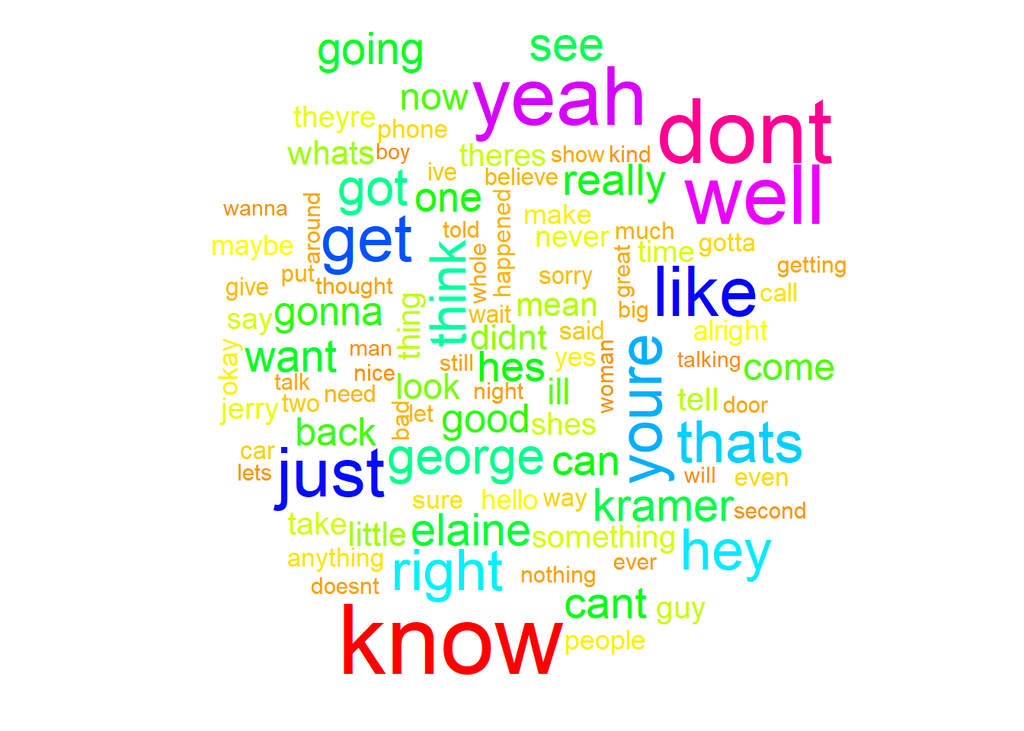

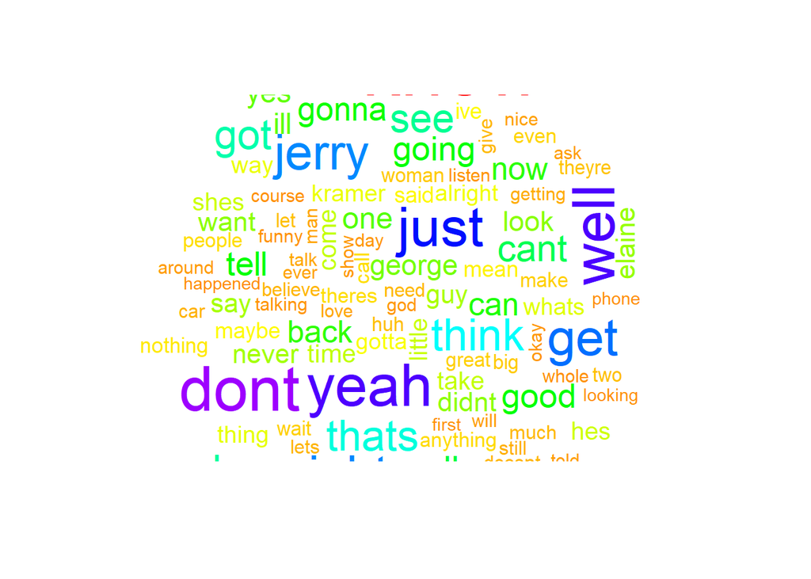

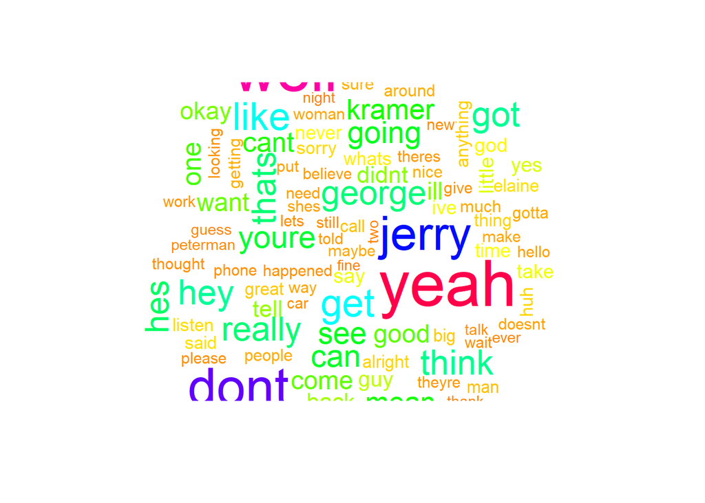

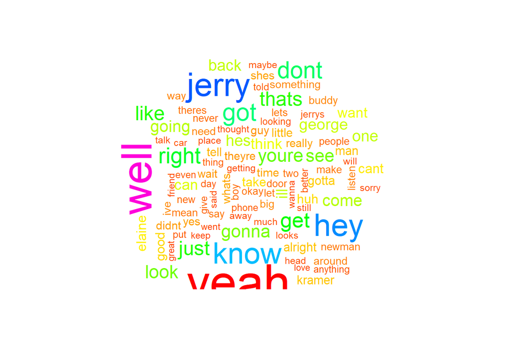

#### Comparison

We then took each filtering of the data and constructed a comparison word cloud.

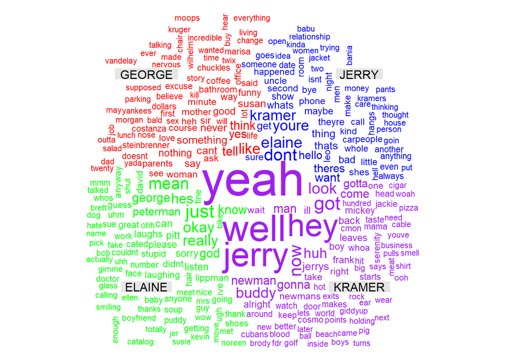

```r
jerry.data <- show %>% filter(grepl("JERRY",Character))
jerry.text.clean <- clean.text(jerry.data$Dialogue)
jerry <- paste(jerry.text.clean, collapse = " ")

george.data <- show %>% filter(grepl("GEORGE",Character))
george.text.clean <- clean.text(george.data$Dialogue)
george <- paste(george.text.clean, collapse = " ")

elaine.data <- show %>% filter(grepl("ELAINE",Character))
elaine.text.clean <- clean.text(elaine.data$Dialogue)
elaine <- paste(elaine.text.clean, collapse = " ")

kramer.data <- show %>% filter(grepl("KRAMER",Character))
kramer.text.clean <- clean.text(kramer.data$Dialogue)
kramer <- paste(kramer.text.clean, collapse = " ")

group <- c(jerry, george, elaine, kramer)
group <- removeWords(group, stopwords("english"))

group.corpus <- Corpus(VectorSource(group))
group.TDM <- TermDocumentMatrix(group.corpus)
group.mat <- as.matrix(group.TDM)
colnames(group.mat) <- c("JERRY", "GEORGE", "ELAINE", "KRAMER")

comparison.cloud(group.mat, random.order=F, colors=c("blue", "red", "green", "purple"), scale=c(4,0.6), title.size=1, max.words=300)
```